# Time Series Analysis

Lizzie

**Suggested Reading:**

Chapter 12 from: Legendre, P. and L. Legendre. 2012. Numerical Ecology. Elsevier. [link] (https://ac.els-cdn.com/B9780444538680500125/1-s2.0-B9780444538680500125-main.pdf?_tid=f5eaeb54-d142-11e7-bee5-00000aab0f6b&acdnat=1511547298_9eabfd069eba80f333a2bc8774adb524)

**Helpful Resources:**

Cochlan, A. Little Book of R for Time Series. 2017. [link](https://a-little-book-of-r-for-time-series.readthedocs.io/en/latest/src/timeseries.html)

Hyndman, R. CRAN Task View: Time Series. [link](https://CRAN.R-project.org/view=TimeSeries)

Hyndman, R. Time Series Data Library (TSDL). [link](https://datamarket.com/data/list/?q=provider:tsdl)

National Ecological Observatory Network (NEON) Data Skills. [link](http://neondataskills.org/time-series/)

National Institute of Standards and Technology (NIST/SEMATECH). Engineering Statistics Handbook. 2012. [link](http://www.itl.nist.gov/div898/handbook/)

### Key Points

#### Definition

A time series is a sequence of successive values representing a variable measured at equally spaced time intervals.

#### Assumptions

- ordered (non-random) sequence
- measurements taken at equally spaced time intervals

#### Purpose

- identify and describe the nature, internal structure that yield the observed data
- *e.g.*, autocorrelation, trend, seasonal variation, etc.
- fit a model to forecast
- predict future values based on the character of the observed values’ sequence

#### Identifying Patterns

##### Pattern analysis: systematic pattern vs. random noise (error)

- filter out noise to reveal pattern

##### Trend analysis: the trend is a general linear or nonlinear component that does not repeat in the sampled time range

1. **smoothing**: averaging the data locally to cancel out nonsystematic variability between individual observations
- *moving average* (MA): most common method; replaces each element of the series with either the simple or weighted average (or unweighted median) of n surrounding elements; n is the width of the smoothing “window”
- *distance-weighted least squares smoothing* or *negative exponentially weighted smoothing*: lesson common methods, applicable when measurement errors are large; filter out noise and convert data into smooth curves that are relatively unbiased by outliers
- *bicubic points*: applicable when a series has a few points that are systematically distributed
2. **fitting function**
- monotonous linear time series: linear function
- monotonous nonlinear: transform data using logarithmic, exponential, or polynomial function to remove nonlinearity

##### Seasonality analysis: seasonality is similar to trend, except the component repeats in systematic intervals over time

- defined as correlational dependency of order *k* between each *i*th element of the series and the (*i-k*)th element (Kendall, 1976); measured by autocorrelation (*i.e*., correlation between the two terms)
- *k* = *lag*: if measurement error is not too large, seasonality emerges in the series as a pattern repeating every *k* elements
- **autocorrelation function (ACF)**: serial correlation coefficents with their standard errors for successive lags in a specifed range of lags; displayed in autocorrelation correlogram (autocorrelogram)
- Note: autocorrelations for consecutive lags are interdependent
- **partial autocorrelation function (PACF)**: extension of autocorrelation that removes dependence on (or autocorrelations among) elements within a lag
- Note: If the lag is 1, there are no intermediate elements within the lag; therefore, the partial autocorrelation equals the autocorrelation. The partial autocorrelation may provides a “cleaner” picture of serial dependencies for individual lags, unconfounded by other serial dependencies.
- Removing serial dependency: to remove serial dependency within a specific lag, replace each *i*th element of the series with the difference from the (*i-k*)th element
- two reasons for such transformations
1. identify hidden nature of seasonal dependencies in the series; removing some of the autocorrelations will change other auto correlations, eliminating them or making other seasonalities more salient
2. to make the series stationary, which is necessary for ARIMA (autoregressive integrated moving average) and other models

##### Multiplicative seasonality: data display seasonality and trend

### Analysis Examples

#### Three time-series datasets:

1. Atmospheric CO2 levels (ppm) measured at Mauna Loa from 1965 to 1980
2. Total annual rainfall (in) measured in London from 1813 to 1912 (“http://robjhyndman.com/tsdldata/hurst/precip1.dat)
3. Volcanic dust veil index (measure of the environemtal impact of volcanic eruptions’ release of dust and aerosols) in the northern hemisphere, measured from 1500 to 1969 (http://robjhyndman.com/tsdldata/annual/dvi.dat)

##### Read time series data

```r
ppm <- read.csv("~/Dropbox/Stanford/Courses/2017 Fall/BIO 202/TimeSeries/data/ppmmaunaloa19651980.csv")
```

##### Store data as a time-series object, specifying frequency and start.

```r
ppmtimeseries <- ts(ppm, frequency=12, start=c(1965))
ppmtimeseries
```

```
##         Jan    Feb    Mar    Apr    May    Jun    Jul    Aug    Sep    Oct
## 1965 319.32 320.36 320.82 322.06 322.17 321.95 321.20 318.81 317.82 317.37
## 1966 319.94 320.98 321.81 323.03 323.36 323.11 321.65 319.64 317.86 317.25
## 1967 321.65 321.81 322.36 323.67 324.17 323.39 321.93 320.29 318.58 318.60
## 1968 321.88 322.47 323.17 324.23 324.88 324.75 323.47 321.34 319.56 319.45
## 1969 323.40 324.21 325.33 326.31 327.01 326.24 325.37 323.12 321.85 321.31
## 1970 324.60 325.57 326.55 327.80 327.80 327.54 326.28 324.63 323.12 323.11
## 1971 326.12 326.61 327.16 327.92 329.14 328.80 327.52 325.62 323.61 323.80
## 1972 326.93 327.83 327.95 329.91 330.22 329.25 328.11 326.39 324.97 325.32
## 1973 328.73 329.69 330.47 331.69 332.65 332.24 331.03 329.36 327.60 327.29
## 1974 329.45 330.89 331.63 332.85 333.28 332.47 331.34 329.53 327.57 327.57
## 1975 330.45 330.97 331.64 332.87 333.61 333.55 331.90 330.05 328.58 328.31
## 1976 331.63 332.46 333.36 334.45 334.82 334.32 333.05 330.87 329.24 328.87
## 1977 332.81 333.23 334.55 335.82 336.44 335.99 334.65 332.41 331.32 330.73
## 1978 334.66 335.07 336.33 337.39 337.65 337.57 336.25 334.39 332.44 332.25
```

[output cut: 19 more lines]

##### Plot the data.

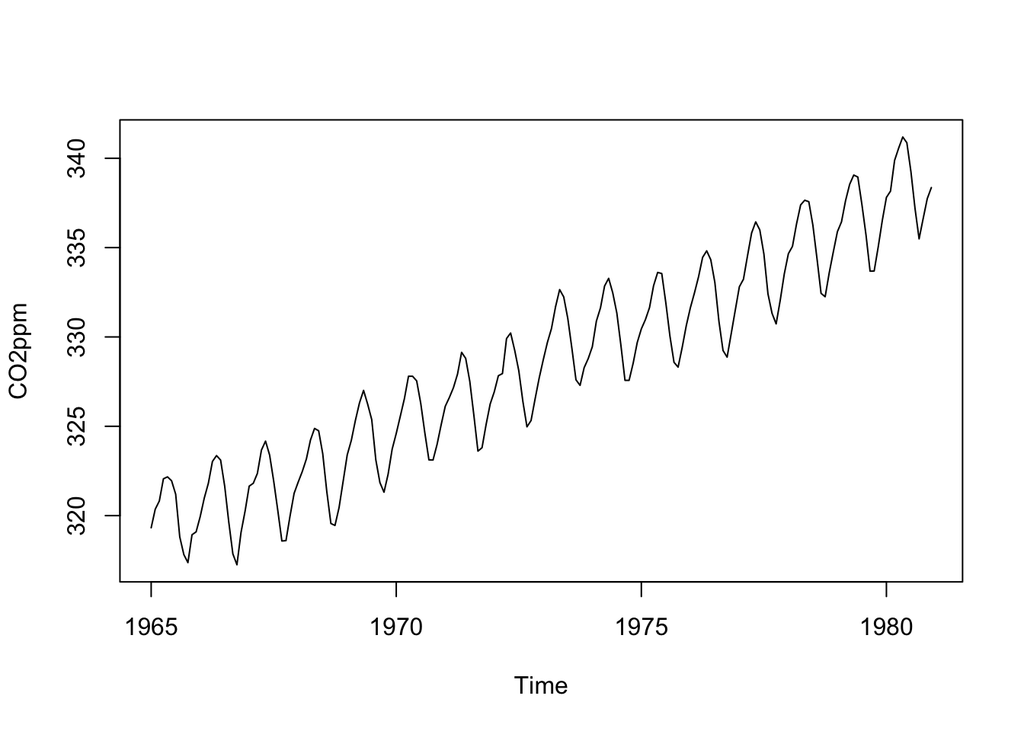

```r
plot.ts(ppmtimeseries)
```

In contrast, the London rain data are not seasonal.

```r
rain <- scan("http://robjhyndman.com/tsdldata/hurst/precip1.dat",skip=1)
rain
```

```
##   [1] 23.56 26.07 21.86 31.24 23.65 23.88 26.41 22.67 31.69 23.86 24.11
##  [12] 32.43 23.26 22.57 23.00 27.88 25.32 25.08 27.76 19.82 24.78 20.12
##  [23] 24.34 27.42 19.44 21.63 27.49 19.43 31.13 23.09 25.85 22.65 22.75
##  [34] 26.36 17.70 29.81 22.93 19.22 20.63 35.34 25.89 18.65 23.06 22.21
##  [45] 22.18 18.77 28.21 32.24 22.27 27.57 21.59 16.93 29.48 31.60 26.25
##  [56] 23.40 25.42 21.32 25.02 33.86 22.67 18.82 28.44 26.16 28.17 34.08
##  [67] 33.82 30.28 27.92 27.14 24.40 20.35 26.64 27.01 19.21 27.74 23.85
##  [78] 21.23 28.15 22.61 19.80 27.94 21.47 23.52 22.86 17.69 22.54 23.28
##  [89] 22.17 20.84 38.10 20.65 22.97 24.26 23.01 23.67 26.75 25.36 24.79
## [100] 27.88
```

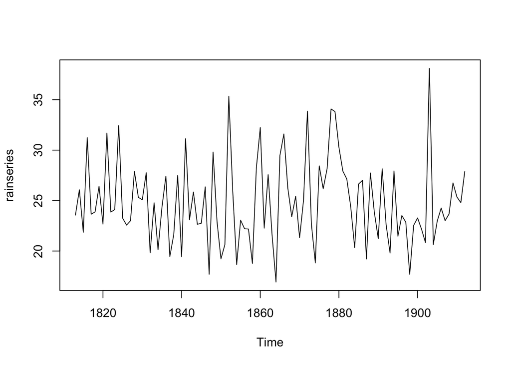

```r
rainseries <- ts(rain,start=c(1813))
plot.ts(rainseries)
```

However, the rain plot’s random fluctuations also appear to remain consistent over time, indicating an additive model is probably appropriate.

#### Decomposing Time Series

Decomposing time series dismantles each sequence into its constituents–trend, irregular, and (if applicable) seaonsal components.

##### Decomposing non-seasonal data: trend and irregular components

Since we can describe the rain time series using an additive model, we can estimate the trend component using the smoothing method of simple moving averages (MA).

In the *TTR* R package, the *SMA()* function applies simple MA to smooth time series: SMA(x, n=10, …), where n denotes order, or number of periods to average over.

```r
#install package TTR()
library("TTR")
rainseriesSMA3 <- SMA(rainseries,n=3)
```

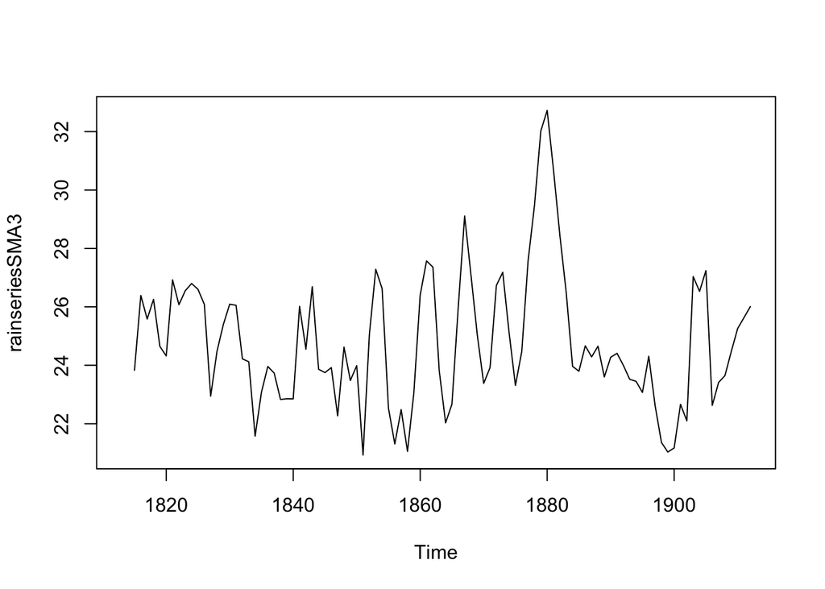

```r
plot.ts(rainseriesSMA3)
```

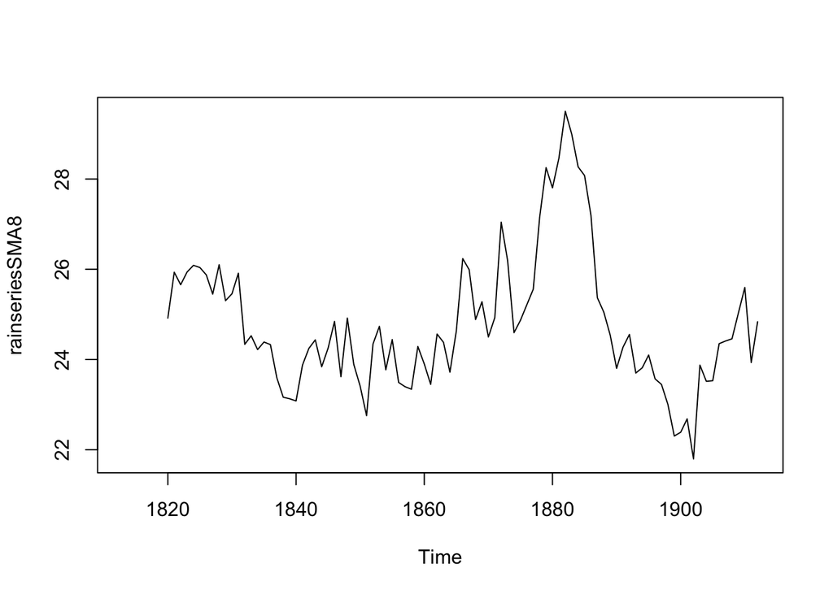

```r
rainseriesSMA8 <- SMA(rainseries,n=8)
plot.ts(rainseriesSMA8)
```

Increasing the order of the function increases the “smoothness” of the plot, yielding a clearer depiction of the trend component.

#### Decomposing seasonal data: trend, irregular, and seasonal components

If an additive model can describe a time series, the *decompose()* R funtion estimates the trend, seasonal, and irregular components of that time series. Therefore, we can apply *decompose()* to the Mauna Loa time series.

```r
ppmtimeseriescomponents <- decompose(ppmtimeseries)
```

*decompose()* returns a list object under which it stores estimates of the seasonal, trend, and irregular components in named elements. Hence, we can inspect the estimated values of each component by specifying its variable.

```r
ppmtimeseriescomponents$seasonal
```

```
##              Jan         Feb         Mar         Apr         May
## 1965 -0.06693519  0.52787037  1.32306481  2.36914815  2.81206481
## 1966 -0.06693519  0.52787037  1.32306481  2.36914815  2.81206481
## 1967 -0.06693519  0.52787037  1.32306481  2.36914815  2.81206481
## 1968 -0.06693519  0.52787037  1.32306481  2.36914815  2.81206481
## 1969 -0.06693519  0.52787037  1.32306481  2.36914815  2.81206481
## 1970 -0.06693519  0.52787037  1.32306481  2.36914815  2.81206481
## 1971 -0.06693519  0.52787037  1.32306481  2.36914815  2.81206481
## 1972 -0.06693519  0.52787037  1.32306481  2.36914815  2.81206481
## 1973 -0.06693519  0.52787037  1.32306481  2.36914815  2.81206481
## 1974 -0.06693519  0.52787037  1.32306481  2.36914815  2.81206481
## 1975 -0.06693519  0.52787037  1.32306481  2.36914815  2.81206481
## 1976 -0.06693519  0.52787037  1.32306481  2.36914815  2.81206481
## 1977 -0.06693519  0.52787037  1.32306481  2.36914815  2.81206481
## 1978 -0.06693519  0.52787037  1.32306481  2.36914815  2.81206481
```

[output cut: 36 more lines]

Plot each component.

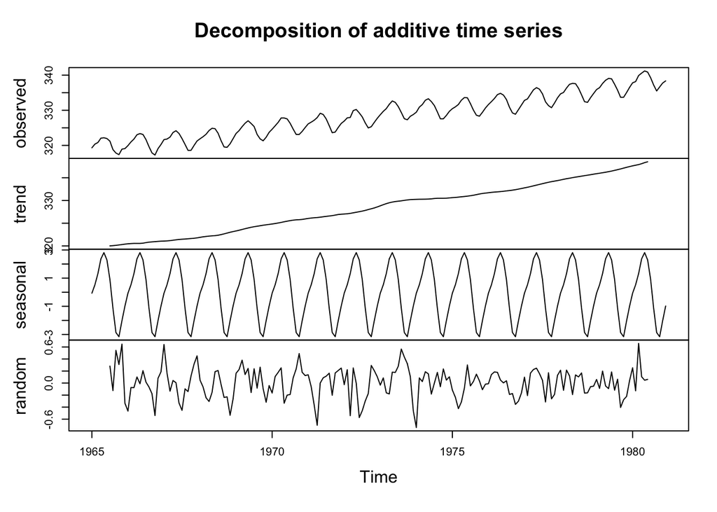

```r
plot(ppmtimeseriescomponents)
```

##### Adjusting seasonality

Again, since we can describe the Mauna Loa CO2 time series using an additive model, we can subtract the estimated seasonal component (calculated by *decompose()*) from the original time series to yield an adjusted time series that only contains the trend and irregular components.

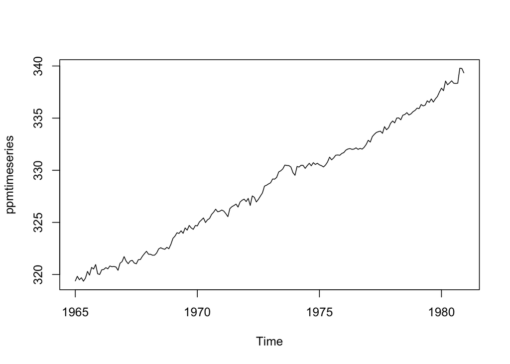

```r
ppmtimeseriescomponents <- decompose(ppmtimeseries)
ppmtimeseriesseasonallyadjusted <- ppmtimeseries - ppmtimeseriescomponents$seasonal
plot(ppmtimeseriesseasonallyadjusted)
```

#### Forecasts using exponential smoothing: short-term forecasts for time-series data

# Simple exponential smoothing

We can use simple exponential smoothing to yield short-term forecasts for the London rain time series, for it is nonseasonal and displays constant variance (can be described by an additive model) and level (the mean hovers around 25 inches).

*Holt-Winters()* estimates the level, slope, and seasonal component at a given time point. Three parameters control smoothing: *alpha* estimates the level (mean), *beta* estimates the trend component’s slope *b*, and *gamma* estimates the seasonal component. *Alpha*, *beta*, and *gamma* range from 0 and 1; low values indicate that recent observations carry reltively little weight regarding forecasted values.

Thus, we can modify *HoltWinters()* to execute simple exponential smoothing by setting *beta* and *gamma* to FALSE, leaving *alpha* to control smoothing.

```r
rainseriesforecasts <- HoltWinters(rainseries, beta=FALSE, gamma=FALSE)
rainseriesforecasts
```

```
## Holt-Winters exponential smoothing without trend and without seasonal component.
##
## Call:
## HoltWinters(x = rainseries, beta = FALSE, gamma = FALSE)
##
## Smoothing parameters:
##  alpha: 0.02412151
##  beta : FALSE
##  gamma: FALSE
##
## Coefficients:
##       [,1]
## a 24.67819
```

*HoltWinters* stores forecasts in named element *fitted*. To inspect the fitted values:

```r
rainseriesforecasts$fitted
```

```
## Time Series:
## Start = 1814
## End = 1912
## Frequency = 1
##          xhat    level
## 1814 23.56000 23.56000
## 1815 23.62054 23.62054
## 1816 23.57808 23.57808
## 1817 23.76290 23.76290
## 1818 23.76017 23.76017
## 1819 23.76306 23.76306
## 1820 23.82691 23.82691
## 1821 23.79900 23.79900
## 1822 23.98935 23.98935
## 1823 23.98623 23.98623
```

[output cut: 89 more lines]

To plot the original time series against the forecasts:

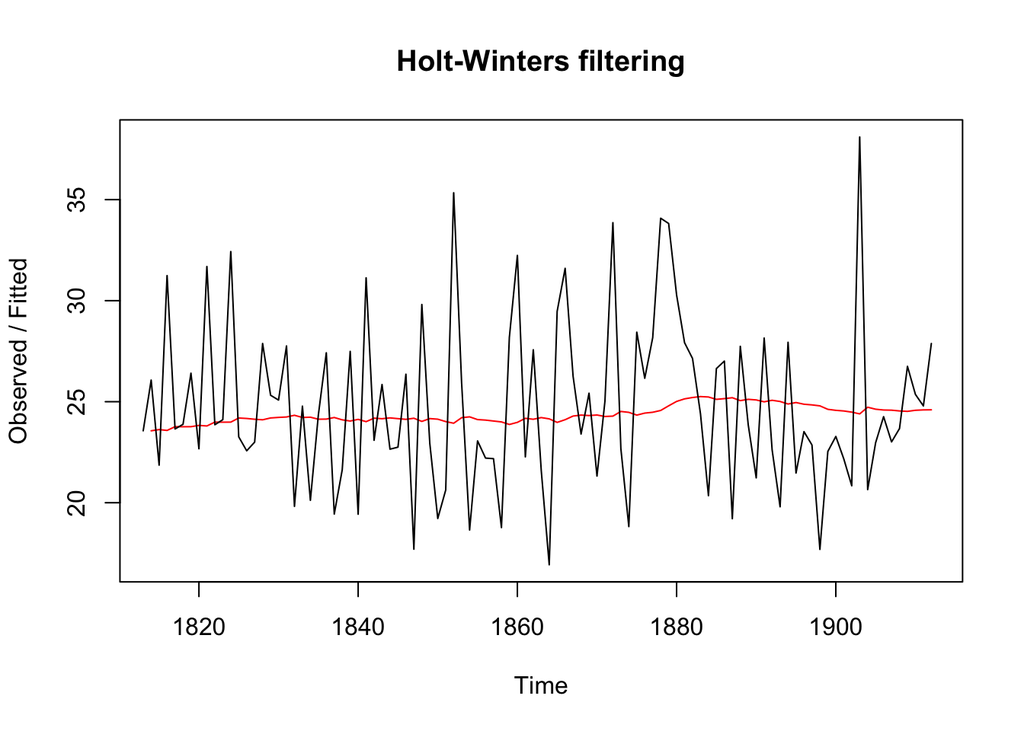

```r
plot(rainseriesforecasts)
```

To calculate the sum of squared errors for the forecast errors:

```r
rainseriesforecasts$SSE
```

```
## [1] 1828.855
```

To modify the forecast window, we can specify the initial value in *HoltWinters()* by changing the *l.start* parameter. For example, 23.56 inches of rain fell in 1813.

```r
HoltWinters(rainseries, beta=FALSE, gamma=FALSE, l.start=23.56)
```

```
## Holt-Winters exponential smoothing without trend and without seasonal component.
##
## Call:
## HoltWinters(x = rainseries, beta = FALSE, gamma = FALSE, l.start = 23.56)
##
## Smoothing parameters:
##  alpha: 0.02412151
##  beta : FALSE
##  gamma: FALSE
##
## Coefficients:
##       [,1]
## a 24.67819
```

We can also modify the time period from which forecasts are drawn by using *forecast()* (originally *forecast.HoltWinters()*) from the *forecast* R package. Thus, we can extend the original London rainfall data time period (1813-1912) to 1920 by adjusting the *h* parameter to 8, adding 8 years.

```r
#install.packages("forecast")
library("forecast")
library("stats")
rainseriesforecasts2 <- forecast(rainseriesforecasts, h=8) #corrected from forecast.HoltWinters()
rainseriesforecasts2
```

```
##      Point Forecast    Lo 80    Hi 80    Lo 95    Hi 95
## 1913       24.67819 19.17493 30.18145 16.26169 33.09470
## 1914       24.67819 19.17333 30.18305 16.25924 33.09715
## 1915       24.67819 19.17173 30.18465 16.25679 33.09960
## 1916       24.67819 19.17013 30.18625 16.25434 33.10204
## 1917       24.67819 19.16853 30.18785 16.25190 33.10449
## 1918       24.67819 19.16694 30.18945 16.24945 33.10694
## 1919       24.67819 19.16534 30.19105 16.24701 33.10938
## 1920       24.67819 19.16374 30.19265 16.24456 33.11182
```

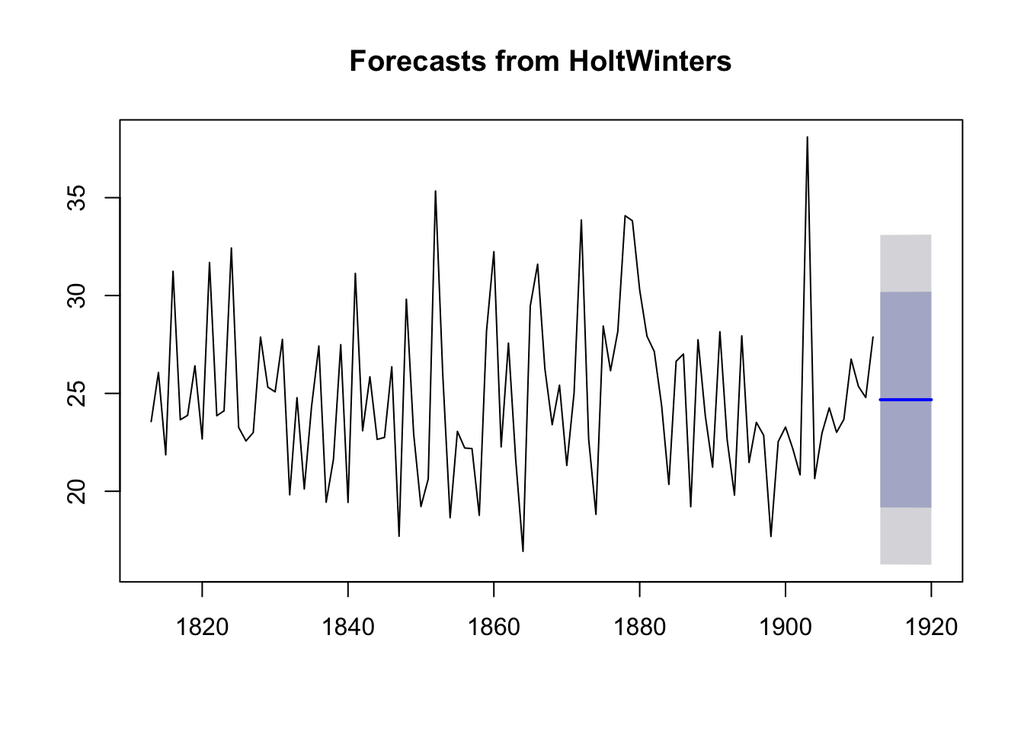

```r
plot(rainseriesforecasts2) #originally plot.forecast()
```

If the predictive model cannot be improved, then no correlations should exist between forecast errors over successive predictions. If correlations are present, another forecasting technique should be used to improve the simple exponential smoothing forecasts. Accordingly, we can calculate a correlogram of the in-sample forecast errors using *acf()*. To specify the maximum lag investigated, modify the *lag-max* parameter in *acf()*.

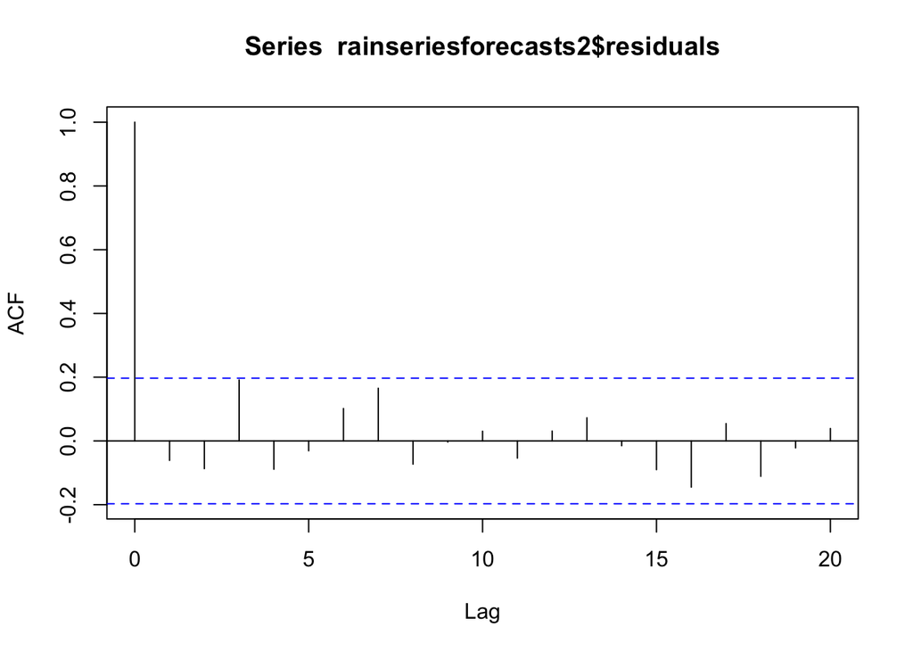

```r
acf(rainseriesforecasts2$residuals, lag.max=20, na.action = na.omit)
```

```r
#need na.action = na.omit because acf works on regularly spaced data, so acf() first expands the time series to a regularly spaced series, inserting NAs as needed
```

To test whether there is significant evidence for non-zero correlations, whether any of a group of autocorrelations of a time series differ from zero, we can run a Ljung-Box test:

```r
Box.test(rainseriesforecasts2$residuals, lag=20, type="Ljung-Box")
```

```
##
##  Box-Ljung test
##
## data:  rainseriesforecasts2$residuals
## X-squared = 17.401, df = 20, p-value = 0.6268
```

Results: Ljung-Box test statistic is 17.4, and the p-value is 0.6, suggesting there is little evidence for non-zero autocorrelations in the in-sample forecast errors at lags 1-20; small p-values (*i.e*., p-value < .05) indicates the possibility of non-zero autocorrelation within the first m lags.

Another step to check whether the predictive model can be improved upon is to investigate whether the forecast errors are normally distributed with mean zero and constant variance. Hence, make a time plot of the in-sample forecast errors to view the variance, and plot a histogram of the forecast errors (with an overlaid normal curve that has mean zero and the same standard deviation as the distribution of forecast errors) to check for normal distribution.

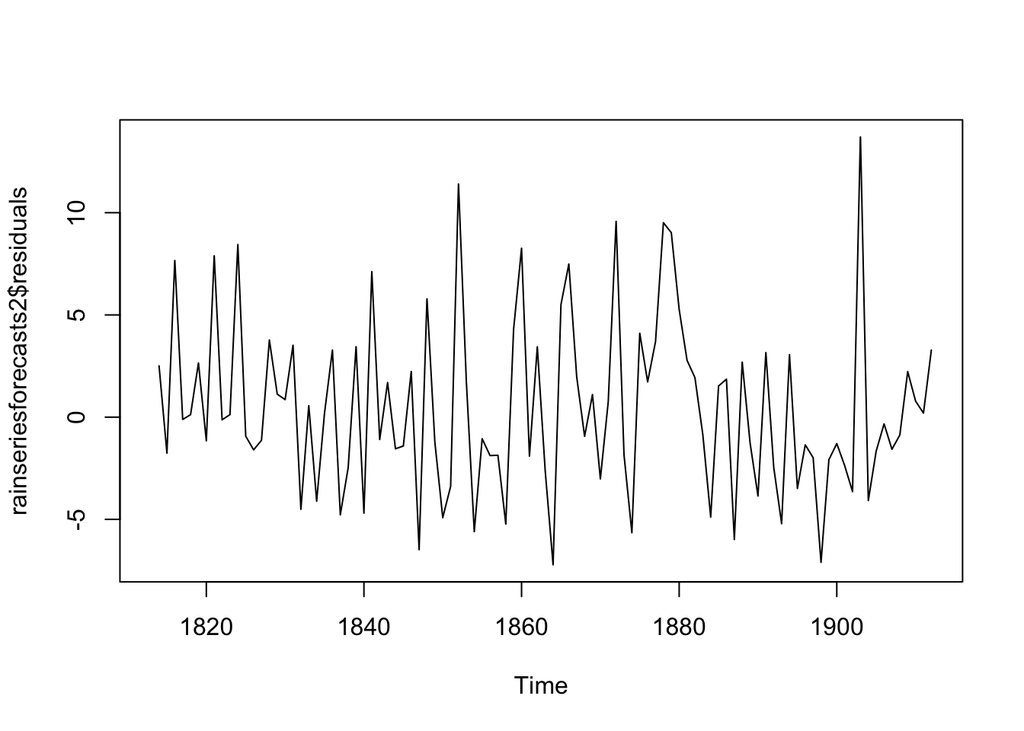

```r
#Check for constant variance over time:
plot.ts(rainseriesforecasts2$residuals)
```

```r
#in-sample forecast errors seem to have roughly constant variance over time, although the sizes of the fluctuations early in the time series (1820-1830) may be slightly smaller than those at later dates (eg. 1840-1850)
```

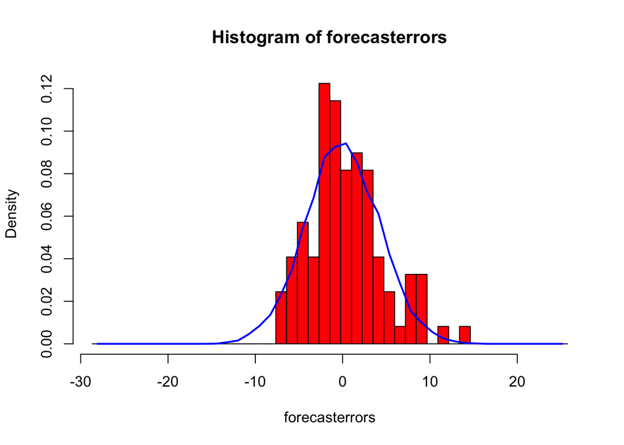

```r
##define an R function “plotForecastErrors()”
plotForecastErrors <- function(forecasterrors)
  {
    # make a histogram of the forecast errors:
  mybinsize <- IQR(forecasterrors, na.rm = TRUE)/4
    mysd   <- sd(forecasterrors, na.rm = TRUE)
    mymin  <- min(forecasterrors, na.rm = TRUE) - mysd*5
    mymax  <- max(forecasterrors, na.rm = TRUE) + mysd*3
    # generate normally distributed data with mean 0 and standard deviation mysd
    mynorm <- rnorm(10000, mean=0, sd=mysd)
    mymin2 <- min(mynorm, na.rm = TRUE)
    mymax2 <- max(mynorm, na.rm = TRUE)
    if (mymin2 < mymin ) { mymin <- mymin2}
    if (mymax2 > mymax) { mymax <- mymax2}
    # make a red histogram of the forecast errors, with the normally distributed data overlaid:
    mybins <- seq(mymin, mymax, mybinsize)
    hist(forecasterrors, col="red", freq=FALSE, breaks=mybins)
    # freq=FALSE ensures the area under the histogram = 1
    # generate normally distributed data with mean 0 and standard deviation mysd
    myhist <- hist(mynorm, plot=FALSE, breaks=mybins)
    # plot the normal curve as a blue line on top of the histogram of forecast errors:
    points(myhist$mids, myhist$density, type="l", col="blue", lwd=2)
}
#plot a histogram (with overlaid normal curve) of the forecast errors for the rainfall predictions
plotForecastErrors(rainseriesforecasts2$residuals)
```

The Ljung-Box test reveals little evdence of non-zero autocorrelations in the in-sample forecast errors, the variances in forecast errors appear roughly constant, and the forecast errors appear normally distributed. Therefore the simple exponential smoothing method likely provides an adequate predictive model for London rainfall.

##### Holt-Winters Exponential Smoothing

Holt-Winters exponential smoothing is used to make short-term forecasts for time series that can be described using an additive model with increasing or decreasing trend and seasonality, such as for the Mauna Loa CO2 time series. Holt-Winters filtering follows the same steps as for exponential smoothing, except *beta* and *gamma* are included to reflect the trend in the seasonal data series.

#### ARIMA Models

Prediction intervals for forecasting based on exponential smoothing methods require the forecast errors to be uncorrelated and normally distributed with mean zero and constant variance.

In contrast, Autoregressive Integrated Moving Average (ARIMA) models include an explicit statistical model for the irregular component of a time series, allowing non-zero autocorrelations in the irregular component. ARIMA models also require stationary time series.

```r
volcanodust <- scan("http://robjhyndman.com/tsdldata/annual/dvi.dat", skip=1)
volcanodust
```

```
##   [1] 200 150 100  50   0   0   0   0   0   0   0   0   0   0   0   0   0
##  [18]   0   0   0   0   0   0   0   0   0   0   0   0   0   0   0   0   0
##  [35]   0  50  50  50   0   0   0   0   0   0   0   0   0   0   0   0   0
##  [52]   0   0 100 500 350 200 100   0   0   0   0   0   0   0   0   0   0
##  [69]   0   0   0   0   0   0   0   0   0   0   0   0   0   0   0   0   0
##  [86]   0 200 150 100  50   0   0   0 200 150 100  50  40  30  20  10 400
## [103] 300 210 110  10  20  50  50  50  40  30  20  10 200 150 100  50   0
## [120]   0   0   0   0   0   0 100  75  50  25   0   0 120  90  60  30   0
## [137]  40  30 120  85 150 400 275 175  75   0  60  45  30  15 100  75  50
## [154]  25   0   0   0   0   0   0 340 255 170  85 130 100  65  30   0   0
## [171]   0   0 200 150 100  50   0   0   0   0 280 210 140  70   0   0   0
## [188]   0   0   0   0   0   0 140 285 205 105  45   0   0   0   0   0   0
## [205]   0   0   0 300 225 150  75   0  80  60  40  20   0 120  90  60  30
## [222] 100  75  50  55  15  15  15  15  15 160 130  90  50   0   0   0   0
## [239]   0   0   0   0   0   0  60  45  30  15   0   0   0   0 200 150 160
## [256] 255 150  95  40  80 110  77  45  13   0   0   0   0   0   0   0   0
## [273]  50  37  25  13   0   0   0 180 135  90  45 400 300 200 160  45  30
## [290]  15   0   0   0   0   0 120 130  90  50 130  90  60  30   0   0   0
## [307]   0   0   0   0   0  80 180 170 170 695 490 375 195  30  15   0 200
## [324] 150 100  70  80  65  50  75  50 200 130  80  40 525 450 375 300 225
## [341] 150  75   0   0   0 100 205 140  90  30   0   0   0   0   0   0 140
## [358] 105  70  35   0 160 120  80  40   0   0   0 160 120  80  40   0   0
## [375]   0 120  90  60  30   0   0   0   0 400 300 240 170  50 170 125  85
## [392]  45  20  15  10   5   0   0  30  25  15   5 180 135  90  45   0  60
## [409]  45  30  15   0  60  45  30  15   0   0   0   0   0   0   0   0   0
## [426]   0   0   0   0   0   0   0   0   0   0   0   0   0   0   0   0   0
## [443]   0   0   0   0   0   0   0   0   0   0   0   0   0   0   0   0   0
## [460]   0   0   0   0 160 120  80  40   0   0   0
```

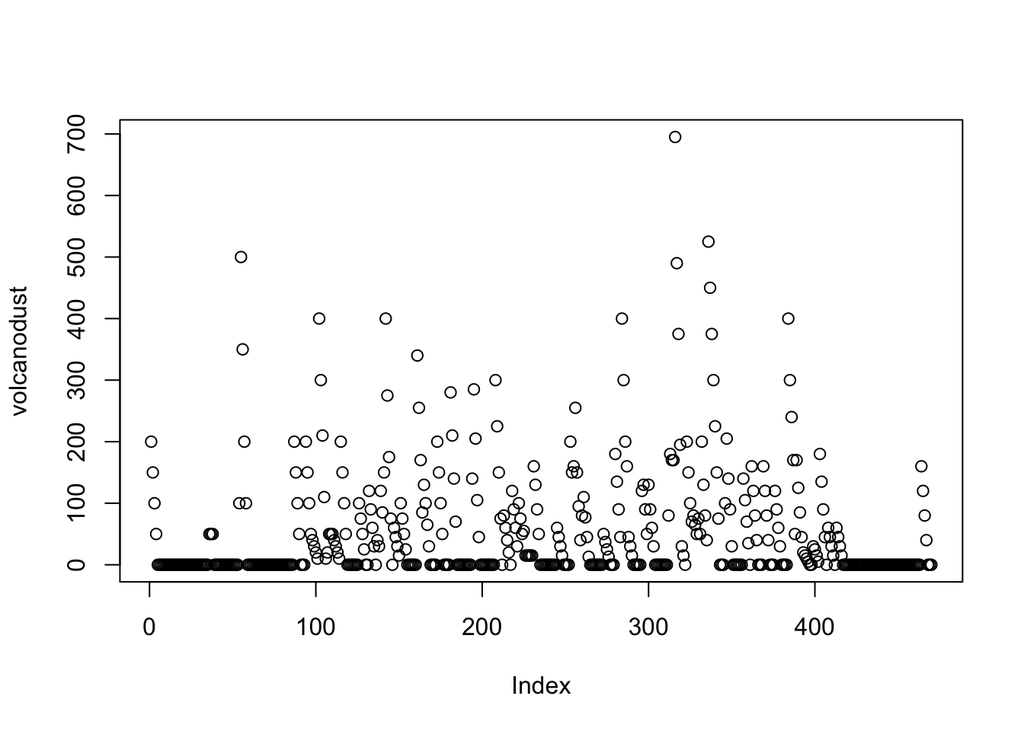

```r
plot(volcanodust)
```

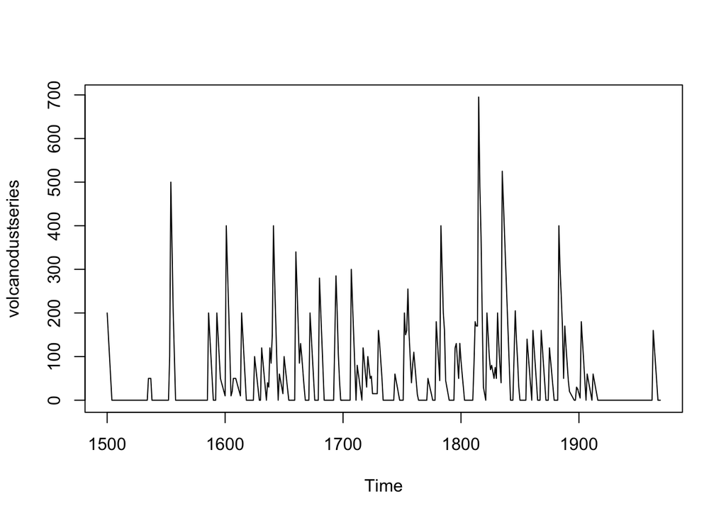

```r
volcanodustseries <- ts(volcanodust,start=c(1500))
plot.ts(volcanodustseries)
```

Given that the random fluctuations are roughly constant in size over time, an additive model is likely appropriate. The time series also appears to be stationary in mean and variance, for the mean and variance are roughly constant over time. Therefore, we can fit an ARIMA model.

To investigate which ARIMA model we should use, plot full and partial correlograms.

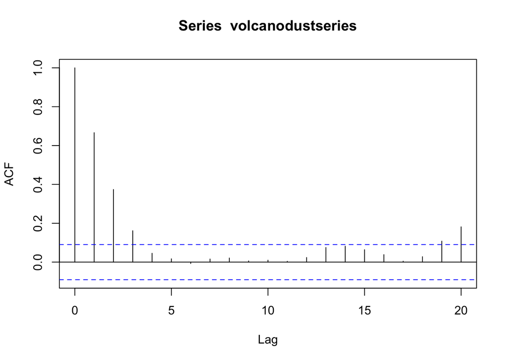

```r
acf(volcanodustseries, lag.max=20)             # plot a correlogram
```

```r
acf(volcanodustseries, lag.max=20, plot=FALSE) # get the values of the autocorrelations
```

```
##
## Autocorrelations of series 'volcanodustseries', by lag
##
##      0      1      2      3      4      5      6      7      8      9
##  1.000  0.666  0.374  0.162  0.046  0.017 -0.007  0.016  0.021  0.006
##     10     11     12     13     14     15     16     17     18     19
##  0.010  0.004  0.024  0.075  0.082  0.064  0.039  0.005  0.028  0.108
##     20
##  0.182
```

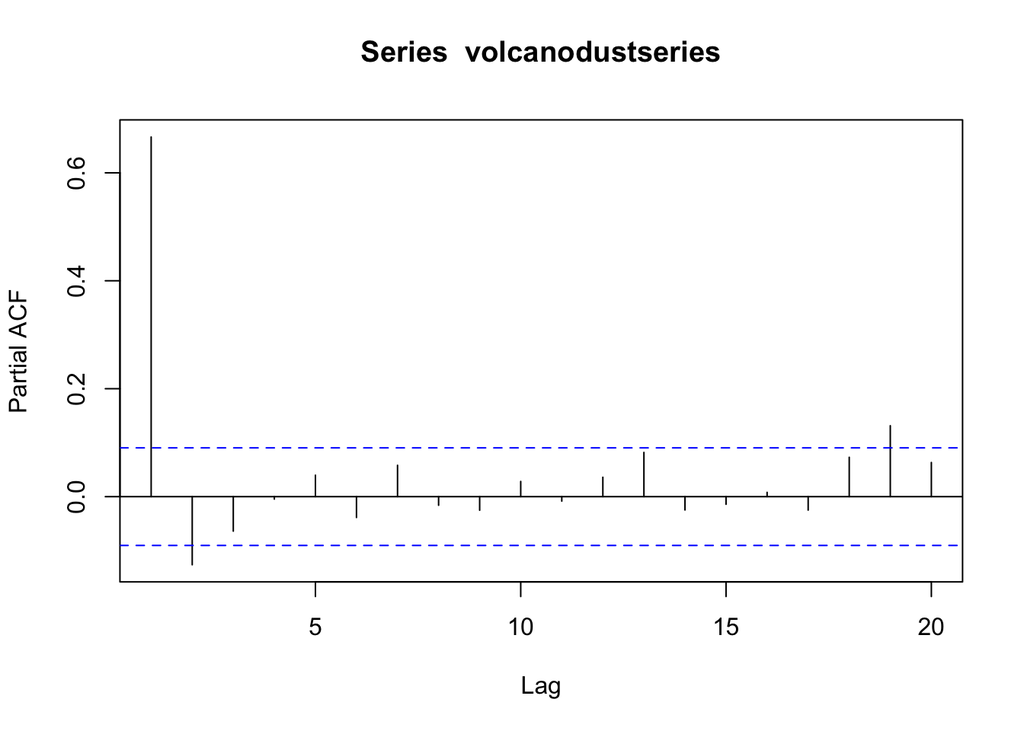

```r
pacf(volcanodustseries, lag.max=20)
```

```r
pacf(volcanodustseries, lag.max=20, plot=FALSE)
```

```
##
## Partial autocorrelations of series 'volcanodustseries', by lag
##
##      1      2      3      4      5      6      7      8      9     10
##  0.666 -0.126 -0.064 -0.005  0.040 -0.039  0.058 -0.016 -0.025  0.028
##     11     12     13     14     15     16     17     18     19     20
## -0.008  0.036  0.082 -0.025 -0.014  0.008 -0.025  0.073  0.131  0.063
```

To fit the ARMA(2,0) model [or ARIMA(2,0,0) model]:

```r
volcanodustseriesarima <- arima(volcanodustseries, order=c(2,0,0))
volcanodustseriesarima
```

```
##
## Call:
## arima(x = volcanodustseries, order = c(2, 0, 0))
##
## Coefficients:
##          ar1      ar2  intercept
##       0.7533  -0.1268    57.5274
## s.e.  0.0457   0.0458     8.5958
##
## sigma^2 estimated as 4870:  log likelihood = -2662.54,  aic = 5333.09
```

Once we’ve fitted the ARIMA(2,0,0) model, we can use *forecast()* for predict future values of the volcanic dust veil index. Let’s extend the original time range (1500-1969) by 31 years (1970-2000).

```r
volcanodustseriesforecasts <- forecast(volcanodustseriesarima, h=31) #edited from forecast.Arima
volcanodustseriesforecasts
```

```
##      Point Forecast     Lo 80    Hi 80     Lo 95    Hi 95
## 1970       21.48131 -67.94860 110.9112 -115.2899 158.2526
## 1971       37.66419 -74.30305 149.6314 -133.5749 208.9033
## 1972       47.13261 -71.57070 165.8359 -134.4084 228.6737
## 1973       52.21432 -68.35951 172.7881 -132.1874 236.6161
## 1974       54.84241 -66.22681 175.9116 -130.3170 240.0018
## 1975       56.17814 -65.01872 177.3750 -129.1765 241.5327
## 1976       56.85128 -64.37798 178.0805 -128.5529 242.2554
## 1977       57.18907 -64.04834 178.4265 -128.2276 242.6057
## 1978       57.35822 -63.88124 178.5977 -128.0615 242.7780
## 1979       57.44283 -63.79714 178.6828 -127.9777 242.8634
## 1980       57.48513 -63.75497 178.7252 -127.9356 242.9059
## 1981       57.50627 -63.73386 178.7464 -127.9145 242.9271
## 1982       57.51684 -63.72330 178.7570 -127.9040 242.9376
## 1983       57.52212 -63.71802 178.7623 -127.8987 242.9429
```

[output cut: 17 more lines]

Plot the orignal time series with the forecasted values.

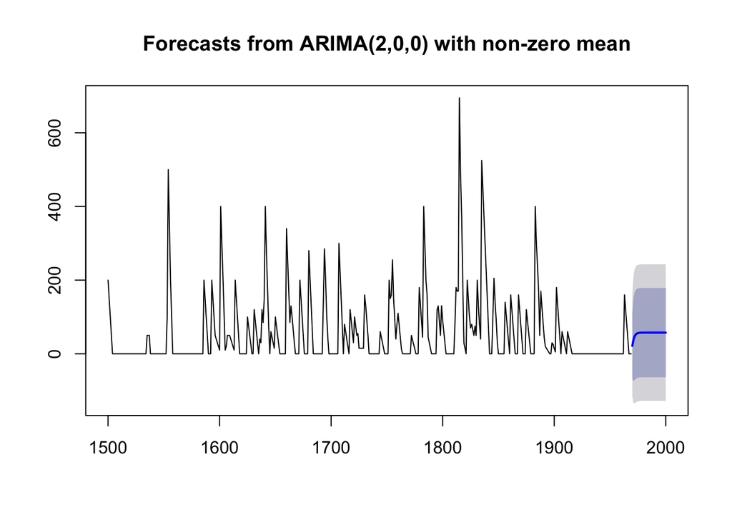

```r
plot(volcanodustseriesforecasts) #edited from plot.forecast
```

Check if the forecast errors are correlated, normally distributed, and have constant variance.

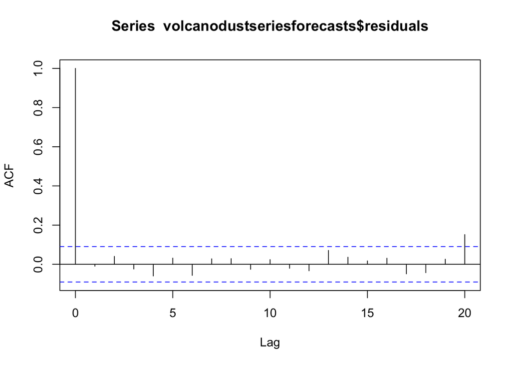

```r
acf(volcanodustseriesforecasts$residuals, lag.max=20)
```

```r
Box.test(volcanodustseriesforecasts$residuals, lag=20, type="Ljung-Box")
```

```
##
##  Box-Ljung test
##
## data:  volcanodustseriesforecasts$residuals
## X-squared = 24.364, df = 20, p-value = 0.2268
```

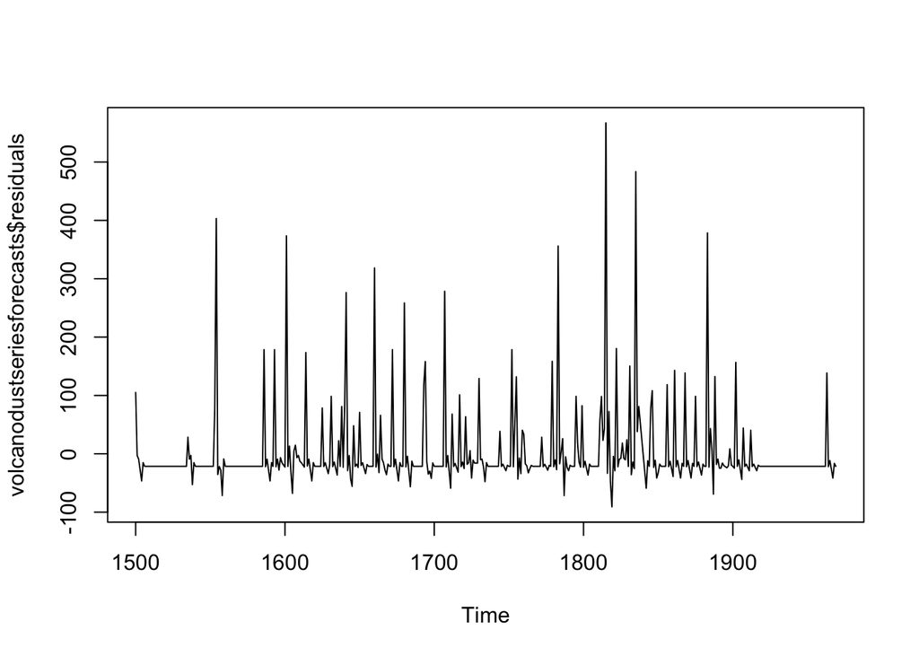

```r
plot.ts(volcanodustseriesforecasts$residuals)            # make time plot of forecast errors
```

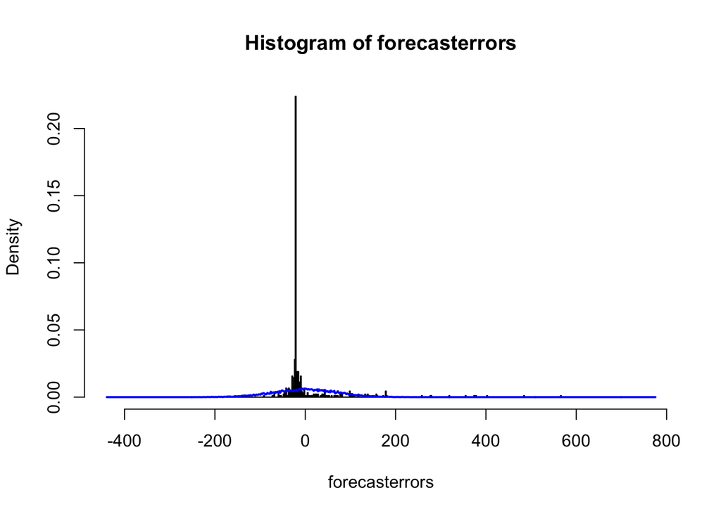

```r
plotForecastErrors(volcanodustseriesforecasts$residuals) # make a histogram
```

The variance appears relatively constant. But is the mean negative?

```r
mean(volcanodustseriesforecasts$residuals)
```

```
## [1] -0.2205417
```

Yep. The distribution is also skewed right. Hence, the forecast errors are not normally distributed with mean zero, suggesting that the ARIMA(2,0,0) model is the not the best model for the volcanic-dust-veil-index time series.

### Discussion Questions

1. How can you use time series analysis for your own data? After learning about its applications, what new research questions could you pose using time series analysis?
2. What are the advantages and disadvantages of smoothing data using moving averages versus medians?
3. How could we improve the ARIMA model for the volcanic-dust-veil-index time series?
4. Can we create a *Tinder*-like app to match ecologists with qualified statisticians for impromptu exponential-smoothing sessions?